# Public Health Indicator Analysis

6/25/20

### Import Libraries

```r
library(ggplot2)
library(Epi)
library(DescTools)
```

### Import dataset

```r
# import dataset
df_anagrafica <- read.csv2("Datasets/DatiAnagrafici.csv", sep = ";", header = TRUE, na="")
df_tumors <- read.csv2("Datasets/RegistroTumori.csv", sep = ";", header = TRUE, na="")
df_sdo <- read.csv2("Datasets/SDO.csv", sep = ";", header = TRUE, na="")
```

### Point 1

Review the datasets and report descriptive statistics in a table for each dataset. Report minimum and maximum observation dates for datasets 2 and 3. Pay attention to the possibility of missing data, inconsistencies between dates, repeated records that could create problems in the linkage and analysis phase. Records with missing or repeated data or inconsistencies between dates (eg. Treatment date prior to the incidence date) must be reported in the report and then deleted for subsequent analyzes.

Descriptive statistics are shown for each dataset.

```r
# Dataset anagrafica
summary(df_anagrafica)
```

```
     idnum        smoke          sex       married       kids       work
 Min.   :   1.0   no :1208   Female:3871   no  : 845   no  :2130   no :3637
 1st Qu.: 969.2   yes:2666   Male  :   3   yes :3018   yes :1737   yes: 237
 Median :1937.5                            NA's:  11   NA's:   7
 Mean   :1937.5
 3rd Qu.:2905.8
 Max.   :3874.0
       education         age
 low        :3461   Min.   : 26.00
 medium/high: 395   1st Qu.: 41.00
 NA's       :  18   Median : 46.00
                    Mean   : 48.21
                    3rd Qu.: 54.00
                    Max.   :108.00
```

```r
# Dataset tumori
summary(df_tumors)
```

```
     idnum              Stadio          incidenza      tipotumore
 Min.   :    3   Stadio I  :1607   20/01/1984:1038   altro  :1982
 1st Qu.: 2964   Stadio II :5507   15/01/1984:1024   colon  :2062
 Median : 5984   Stadio III:1197   14/01/1984:1019   polmone:2072
 Mean   : 5975   Stadio IV :1687   13/01/1984:1015   seno   :3886
 3rd Qu.: 8965   NA's      :   7   16/01/1984:1011   NA's   :   3
 Max.   :12000                     (Other)   :4893
                                   NA's      :   5
```

```r
# Dataset SDO
summary(df_sdo)
```

```
     idnum               Prestazione     dataprestazione      dimissione
 Min.   :    3   chemioterapica:1988   14/02/1984: 194   13/07/1984: 219
 1st Qu.: 2966   chirurgica    :3318   22/02/1984: 183   11/07/1984: 206
 Median : 5986   radioterapica :4696   17/02/1984: 180   15/07/1984: 204
 Mean   : 5976                         16/02/1984: 176   12/07/1984: 199
 3rd Qu.: 8966                         13/02/1984: 175   17/07/1984: 196
 Max.   :12000                         (Other)   :9093   (Other)   :8975
                                       NA's      :   1   NA's      :   3
    ospedale
 Min.   :1.000
 1st Qu.:3.000
 Median :5.000
 Mean   :5.007
 3rd Qu.:7.000
 Max.   :9.000
```

A cleaning phase of the various datasets is performed, eliminating null values and inconsistencies.

#### Personal data

In the dataset there are records with missing values for the columns *married*, *kids* and *education* that must be eliminated.

```r
# Record indices with missing values
missing_anagrafica <- sort(unique(c(which(is.na(df_anagrafica$married)),
                                    which(is.na(df_anagrafica$kids)),
                                    which(is.na(df_anagrafica$education)))))

# Record with missing values
df_anagrafica[missing_anagrafica,]
```

|  | idnum | smoke | sex | married | kids | work | education | age |
| --- | --- | --- | --- | --- | --- | --- | --- | --- |
| 4 | 4 | yes | Female | no | no | no | NA | 52 |
| 6 | 6 | yes | Female | no | no | no | NA | 46 |
| 7 | 7 | yes | Female | no | yes | no | NA | 62 |
| 8 | 8 | yes | Female | no | yes | no | NA | 44 |
| 9 | 9 | yes | Female | no | no | no | NA | 29 |
| 10 | 10 | yes | Female | yes | yes | no | NA | 35 |
| 11 | 11 | yes | Female | yes | yes | no | NA | 36 |
| 13 | 13 | yes | Female | yes | no | no | NA | 50 |
| 14 | 14 | yes | Female | yes | no | yes | NA | 56 |
| 15 | 15 | no | Female | no | no | no | NA | 51 |

[output cut: 26 more lines]

Duplicate records are checked.

```r
df_anagrafica[duplicated(df_anagrafica),]
```

| idnum | smoke | sex | married | kids | work | education | age |
| --- | --- | --- | --- | --- | --- | --- | --- |

There are no duplicate records. The clean dataframe is defined for analysis.

```r
df_anagrafica_clear <- df_anagrafica[-missing_anagrafica,]
```

With a total of 3838 record.

#### Tumors

The *incidenza* column is changed to date

```r
df_tumors$incidenza = as.Date(df_tumors$incidenza, "%d/%m/%Y")
```

There are missing values for the *stadio*, *tipotumore* and *incidenza* columns

```r
missing_tumors <- sort(unique(c(which(is.na(df_tumors$Stadio)),
                                which(is.na(df_tumors$tipotumore)),
                                which(is.na(df_tumors$incidenza)))))

# Record with missing values
df_tumors[missing_tumors,]
```

|  | idnum | Stadio | incidenza | tipotumore |
| --- | --- | --- | --- | --- |
| 1506 | 1260 | NA | 1984-01-17 | altro |
| 1509 | 5594 | NA | 1984-01-20 | colon |
| 1622 | 6606 | NA | 1984-01-17 | altro |
| 1624 | 5804 | NA | 1984-01-16 | seno |
| 9833 | 582 | Stadio I |  | seno |
| 9925 | 1162 | Stadio II |  | seno |
| 10000 | 5102 | NA |  | NA |
| 10001 | 5072 | NA |  | NA |
| 10002 | 4111 | NA |  | NA |

```r
# Creating the dataframe without missing values
df_tumors_clear <- df_tumors[-missing_tumors,]
```

In total the number of deleted records are 9. Duplicate records are checked.

```r
# Indices of duplicate records
dup_ind <- duplicated(df_tumors_clear)

# Duplicate records are
df_tumors_clear[dup_ind,]
```

|  | idnum | Stadio | incidenza | tipotumore |
| --- | --- | --- | --- | --- |
| 10003 | 1933 | Stadio I | 1984-01-15 | seno |
| 10004 | 363 | Stadio II | 1984-01-14 | seno |
| 10005 | 192 | Stadio IV | 1984-01-20 | seno |

```r
# Elimination of duplicates
df_tumors_clear <- unique(df_tumors_clear)
```

With a total of 9993 record.

#### SDO

The *dataprestazione* and *dimissione* columns are converted to dates.

```r
df_sdo$dataprestazione = as.Date(df_sdo$dataprestazione, "%d/%m/%Y")
df_sdo$dimissione = as.Date(df_sdo$dimissione, "%d/%m/%Y")
```

Missing values for the columns *dataprestazione*, *dimissione*.

```r
missing_sdo <- sort(unique(c(which(is.na(df_sdo$dataprestazione)),
                             which(is.na(df_sdo$dimissione)))))

# Record with missing values
df_sdo[missing_sdo,]
```

|  | idnum | Prestazione | dataprestazione | dimissione | ospedale |
| --- | --- | --- | --- | --- | --- |
| 7 | 4402 | chemioterapica | 1984-02-29 |  | 8 |
| 17 | 2633 | chemioterapica | 1984-02-22 |  | 6 |
| 4263 | 567 | chirurgica | 1984-02-13 |  | 9 |
| 9378 | 7261 | radioterapica |  | 1984-07-08 | 1 |

```r
# Creating the dataframe without missing values
df_sdo_clear <- df_sdo[-missing_sdo,]
```

There are no duplicate records.

```r
# duplicate records
df_sdo_clear[duplicated(df_sdo_clear),]
```

| idnum | Prestazione | dataprestazione | dimissione | ospedale |
| --- | --- | --- | --- | --- |

There are inconsistencies between the dates of the service and the dates of discharge.

```r
date_no_ok <- df_sdo_clear$dataprestazione > df_sdo_clear$dimissione

# Records with inconsistent dates are
df_sdo_clear[date_no_ok,]
```

|  | idnum | Prestazione | dataprestazione | dimissione | ospedale |
| --- | --- | --- | --- | --- | --- |
| 746 | 5377 | radioterapica | 1984-07-22 | 1984-07-21 | 6 |
| 809 | 4456 | chirurgica | 1984-07-15 | 1984-07-01 | 3 |
| 1057 | 2813 | radioterapica | 1984-09-19 | 1984-09-13 | 3 |
| 1103 | 245 | chemioterapica | 1984-07-19 | 1984-07-17 | 1 |
| 1129 | 8468 | chemioterapica | 1984-07-15 | 1984-07-01 | 9 |
| 1152 | 2336 | chirurgica | 1984-09-05 | 1984-07-18 | 2 |
| 2158 | 10093 | radioterapica | 1984-08-23 | 1984-07-10 | 1 |
| 2188 | 11996 | chirurgica | 1984-07-12 | 1984-07-06 | 5 |
| 2967 | 5943 | chirurgica | 1984-07-20 | 1984-07-13 | 5 |
| 3054 | 2243 | chemioterapica | 1984-07-24 | 1984-07-20 | 7 |

[output cut: 32 more lines]

```r
# These records are deleted
df_sdo_clear <- df_sdo_clear[-date_no_ok,]
```

The minimum and maximum observation dates are calculated for the tumor and SDO datasets.

```r
# data for the tumor dataset
max_data_tumors <- df_tumors_clear[which.max(df_tumors_clear$incidenza), 'incidenza']
mim_data_tumors <- df_tumors_clear[which.min(df_tumors_clear$incidenza), 'incidenza']
diff_tumors <- max_data_tumors - mim_data_tumors

# performance date for the tumor dataset
max_data_sdo_dataprestazione <- df_sdo_clear[which.max(df_sdo_clear$dataprestazione),'dataprestazione']
mim_data_sdo_dataprestazione <- df_sdo_clear[which.min(df_sdo_clear$dataprestazione),'dataprestazione']
diff_sdo_dataprestazione <- max_data_sdo_dataprestazione - mim_data_sdo_dataprestazione

# discharge for the tumors dataset
max_data_sdo_dimissione <- df_sdo_clear[which.max(df_sdo_clear$dimissione),'dimissione']
mim_data_sdo_dimissione <- df_sdo_clear[which.min(df_sdo_clear$dimissione),'dimissione']
diff_sdo_dimissione <- max_data_sdo_dimissione - mim_data_sdo_dimissione

# Creating a complete dataframe
df_date <- data.frame(c("tumor incidence date", "sdo performance date", "sdo discharge date"),
                c(mim_data_tumors, mim_data_sdo_dataprestazione, mim_data_sdo_dimissione),
                c(max_data_tumors, max_data_sdo_dataprestazione, max_data_sdo_dimissione),
                c(diff_tumors, diff_sdo_dataprestazione, diff_sdo_dimissione))
colnames(df_date) <- c("Dates", "Minimum date", "Maximum date", "Difference in days")

df_date
```

| Dates | Minimum date | Maximum date | Difference in days |
| --- | --- | --- | --- |
| tumor incidence date | 1984-01-11 | 1984-01-20 | 9 days |
| sdo performance date | 1984-01-22 | 1984-10-07 | 259 days |
| sdo discharge date | 1984-06-22 | 1985-02-12 | 235 days |

### Point 2

Record the linkage of the 3 datasets with the aim of building the indicator *Breast cancer removal surgery within 60 days from the diagnosis date* on a monthly basis for the incidents in January 1984.

The linkage record of the three clean datasets is performed.

```r
df_merge <- merge(x = df_anagrafica_clear, y = df_tumors_clear, by = "idnum", all.x = TRUE)
df_final <- merge(x = df_merge, y = df_sdo_clear, by = "idnum", all.x = TRUE)
head(df_final)
```

|  | idnum | smoke | sex | married | kids | work | education | age | Stadio | incidenza | tipotumore | Prestazione | dataprestazione | dimissione | ospedale |
| --- | --- | --- | --- | --- | --- | --- | --- | --- | --- | --- | --- | --- | --- | --- | --- |
| 1 | 1 | yes | Female | yes | no | no | medium/high | 45 | NA |  | NA | NA |  |  | NA |
| 2 | 2 | no | Female | yes | no | no | low | 44 | NA |  | NA | NA |  |  | NA |
| 3 | 3 | no | Female | no | no | no | low | 38 | Stadio II | 1984-01-13 | polmone | radioterapica | 1984-02-07 | 1984-08-11 | 8 |
| 4 | 5 | no | Female | no | no | no | medium/high | 49 | Stadio II | 1984-01-13 | seno | radioterapica | 1984-02-29 | 1984-07-14 | 1 |
| 5 | 12 | yes | Female | yes | yes | no | medium/high | 62 | NA |  | NA | NA |  |  | NA |
| 6 | 18 | no | Female | yes | no | no | low | 42 | Stadio III | 1984-01-19 | seno | chirurgica | 1984-02-12 | 1984-08-10 | 6 |

It is verified that the treatment date is later than the tumor incidence date, records for which this is not true will be removed from the dataset.

```r
df_final[
    !is.na(df_final$dataprestazione) &
    !is.na(df_final$incidenza) &
    df_final$dataprestazione < df_final$incidenza, ]
```

| idnum | smoke | sex | married | kids | work | education | age | Stadio | incidenza | tipotumore | Prestazione | dataprestazione | dimissione | ospedale |
| --- | --- | --- | --- | --- | --- | --- | --- | --- | --- | --- | --- | --- | --- | --- |

There is no record with this inconsistency.

The indicator is built on a monthly basis for incidents in January 1984. The denominator is defined as the number of female subjects with breast cancer occurring between 01/01/1984 and 31/01/1984, in stage I or II, who have undergone surgery

```r
# Calculation of the denominator
den_ind <- which(
  df_final$sex == "Female" & df_final$tipotumore == "seno" &
  (df_final$Stadio == "Stadio I" | df_final$Stadio == "Stadio II") &
  df_final$incidenza <= as.Date("31/01/1984", format = "%d/%m/%Y") &
  df_final$incidenza >= as.Date("01/01/1984", format = "%d/%m/%Y") &
  df_final$Prestazione == "chirurgica")

den <- df_final[den_ind,]
nrow(den)
```

```
[1] 311
```

The numerator is defined as the number of all subjects in the denominator with an interval between the incidence date and the intervention date ≤ 60 days.

```r
# Calculation of the denominator
num_ind <- which(den$dataprestazione - den$incidenza <= 60)

num <- den[num_ind,]

nrow(num)
```

```
[1] 172
```

The indicator and confidence interval are calculated with a 95% confidence level.

```r
ind <- as.data.frame(BinomCI(nrow(num), nrow(den), conf.level = 0.95))

ind
```

| est | lwr.ci | upr.ci |
| --- | --- | --- |
| 0.5530547 | 0.4974857 | 0.607329 |

### Point 3

Calculate the indicator for hospital and give a graphic representation, including the indicator calculated on the entire dataset as the reference value in the graph.

```r
num
```

|  | idnum | smoke | sex | married | kids | work | education | age | Stadio | incidenza | tipotumore | Prestazione | dataprestazione | dimissione | ospedale |
| --- | --- | --- | --- | --- | --- | --- | --- | --- | --- | --- | --- | --- | --- | --- | --- |
| 9 | 21 | yes | Female | yes | yes | no | medium/high | 45 | Stadio II | 1984-01-14 | seno | chirurgica | 1984-03-11 | 1984-08-25 | 2 |
| 18 | 30 | yes | Female | yes | yes | no | low | 71 | Stadio II | 1984-01-11 | seno | chirurgica | 1984-02-18 | 1984-09-23 | 8 |
| 44 | 56 | yes | Female | yes | yes | yes | low | 40 | Stadio II | 1984-01-13 | seno | chirurgica | 1984-02-26 | 1984-09-06 | 4 |
| 66 | 85 | yes | Female | yes | no | no | low | 39 | Stadio II | 1984-01-13 | seno | chirurgica | 1984-02-23 | 1984-07-09 | 4 |
| 76 | 95 | yes | Female | yes | no | no | low | 45 | Stadio II | 1984-01-13 | seno | chirurgica | 1984-02-22 | 1984-10-23 | 6 |
| 92 | 111 | no | Female | yes | no | no | low | 73 | Stadio I | 1984-01-18 | seno | chirurgica | 1984-02-16 | 1984-07-06 | 4 |
| 102 | 121 | yes | Female | yes | no | no | low | 47 | Stadio II | 1984-01-18 | seno | chirurgica | 1984-02-29 | 1984-08-10 | 1 |
| 129 | 148 | yes | Female | yes | no | no | low | 56 | Stadio II | 1984-01-17 | seno | chirurgica | 1984-02-16 | 1984-08-21 | 7 |
| 140 | 159 | yes | Female | no | no | no | low | 52 | Stadio II | 1984-01-11 | seno | chirurgica | 1984-03-03 | 1984-10-12 | 3 |
| 143 | 162 | yes | Female | yes | yes | no | low | 38 | Stadio I | 1984-01-20 | seno | chirurgica | 1984-02-11 | 1984-07-30 | 4 |

[output cut: 162 more lines]

The differentiated indicator per hospital is calculated

```r
# Grouping by hospital
df_group_osp <- merge(aggregate(num$ospedale, by=list(Category=num$ospedale), FUN=length),
                      aggregate(den$ospedale, by=list(Category=den$ospedale), FUN=length),
                      by = "Category",)

colnames(df_group_osp) <- c("Hospital", "Numerator", "Denominator")
df_group_osp$Hospital <- as.factor(df_group_osp$Hospital)

df_group_osp
```

| Hospital | Numerator | Denominator |
| --- | --- | --- |
| 1 | 18 | 39 |
| 2 | 18 | 28 |
| 3 | 16 | 33 |
| 4 | 24 | 46 |
| 5 | 13 | 23 |
| 6 | 18 | 33 |
| 7 | 18 | 29 |
| 8 | 27 | 42 |
| 9 | 20 | 38 |

For each hospital, the indicator and the relative confidence interval are calculated

```r
df_indicatore <- as.data.frame(BinomCI(df_group_osp$Numerator,
                           df_group_osp$Denominator,
                           conf.level = 0.95))

df_group_osp$Indicator <- df_indicatore$est
df_group_osp$lowerCI <- df_indicatore$lwr.ci
df_group_osp$upperCI <- df_indicatore$upr.ci

df_group_osp
```

| Hospital | Numerator | Denominator | Indicator | lowerCI | upperCI |
| --- | --- | --- | --- | --- | --- |
| 1 | 18 | 39 | 0.4615385 | 0.3156689 | 0.6143055 |
| 2 | 18 | 28 | 0.6428571 | 0.4583031 | 0.7929417 |
| 3 | 16 | 33 | 0.4848485 | 0.3250404 | 0.6478162 |
| 4 | 24 | 46 | 0.5217391 | 0.3813741 | 0.6587531 |
| 5 | 13 | 23 | 0.5652174 | 0.3681138 | 0.7436536 |
| 6 | 18 | 33 | 0.5454545 | 0.3798594 | 0.7015706 |
| 7 | 18 | 29 | 0.6206897 | 0.4400254 | 0.7731198 |
| 8 | 27 | 42 | 0.6428571 | 0.4916637 | 0.7701081 |
| 9 | 20 | 38 | 0.5263158 | 0.3725897 | 0.6752098 |

The various calculated indicators are shown.

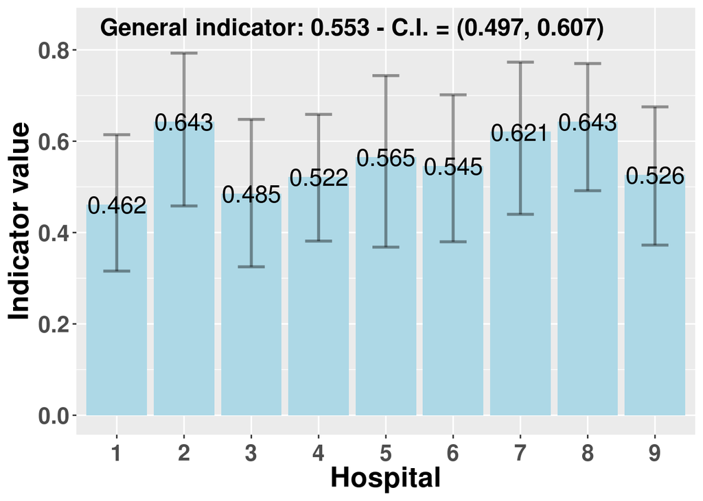

```r
p <- ggplot(df_group_osp, aes(x=Hospital, y=Indicator)) +
  geom_col(fill="light blue")

p + geom_text(aes(label = round(Indicator, 3)), size=6) +
  annotate("text", x = 4.5, y = 0.85, size=6, fontface="bold",
             label = paste0("General indicator: ", round(ind[1], 3),
                            " - C.I. = (", round(ind[2], 3), ", ", round(ind[3], 3), ")")) +
  geom_errorbar( aes(x=Hospital, ymin=lowerCI, ymax=upperCI), width=0.4, colour="black", alpha=0.4, size=1) +
  ylab("Indicator value") +
  theme(axis.title.x = element_text(face="bold", size=20),
        axis.text.x  = element_text(vjust=0.5, face="bold", size=16),
        axis.title.y = element_text(face="bold", size=20),
        axis.text.y  = element_text(vjust=0.5, face="bold", size=16))
```

### Point 4

Use the dataset obtained to evaluate the association on an individual level between the level of education and the value of the indicator.

#### Quale misura di effetto è possibile stimare?

The **odds ratio** is used to calculate the association, in this way we want to understand if different levels of education have a statistically significant impact on the calculated indicator.

```r
# The intervention variable is created based on the calculated indicator
den$surgery <- ifelse(rownames(den) %in% rownames(num), 1, 0)
```

The odds ratio is calculated

```r
t <- twoby2(den$education,den$surgery)
```

```
2 by 2 table analysis:
------------------------------------------------------
Outcome   : 0
Comparing : low vs. medium/high

              0   1    P(0) 95% conf. interval
low         120 149  0.4461    0.3877   0.5060
medium/high  19  23  0.4524    0.3103   0.6027

                                    95% conf. interval
             Relative Risk:  0.9861    0.6891   1.4112
         Sample Odds Ratio:  0.9749    0.5072   1.8740
Conditional MLE Odds Ratio:  0.9750    0.4824   1.9903
    Probability difference: -0.0063   -0.1654   0.1461

             Exact P-value: 1.0000
        Asymptotic P-value: 0.9393
------------------------------------------------------
```

The odds ratio is 0.975, furthermore, the confidence interval contains the value 1 and therefore the odds ratio is not statistically different from 1. The level of education therefore does not affect the event.

#### Calculate the same effect measure, this time adjusted for the only *working* variable, using the Mantel Haenszel method.

The three-dimensional contingency table is created considering also the work variable.

```r
cont_table <- table(education = den$education,
                    intervento = den$surgery,
                    work = den$work)

cont_table
```

```
, , work = no

             intervento
education       0   1
  low         109 140
  medium/high  19  21

, , work = yes

             intervento
education       0   1
  low          11   9
  medium/high   0   2
```

**Breslow-Day** homogeneity test is carried out

```r
BreslowDayTest(cont_table)
```

```
    Breslow-Day test on Homogeneity of Odds Ratios

data:  cont_table
X-squared = 2.3849, df = 1, p-value = 0.1225
```

The **p-value** is greater than 0.05, therefore the null hypothesis of homogeneity between the groups cannot be rejected.

**Mantel Haenszel**’s test is performed to obtain the value of his statistic, the combined p-value and odds ratio.

```r
mh_test <- mantelhaen.test(cont_table)
mh_test
```

```
    Mantel-Haenszel chi-squared test without continuity correction

data:  cont_table
Mantel-Haenszel X-squared = 0.008936, df = 1, p-value = 0.9247
alternative hypothesis: true common odds ratio is not equal to 1
95 percent confidence interval:
 0.5055879 1.8578297
sample estimates:
common odds ratio
        0.9691729
```

The statistic p-value is greater than 0.05. The null hypothesis is not rejected, namely that the OR of the two tables is not statistically different and the working variable does not affect the outcome.

#### Estimate and interpret this effect measure, adjusted for all the available variables that you consider appropriate to include as potential confounders, using a logistic regression model.

As possible confounding variables we consider: the age, the stage of the tumor and the hospital where the service was performed.

```r
model1 <- glm(surgery ~  age + factor(Stadio) + factor(ospedale),
                     data = den, family = "binomial")
summary(model1)
```

```
Call:
glm(formula = surgery ~ age + factor(Stadio) + factor(ospedale),
    family = "binomial", data = den)

Deviance Residuals:
    Min       1Q   Median       3Q      Max
-1.5738  -1.2437   0.8488   1.0645   1.5736

Coefficients:
                        Estimate Std. Error z value Pr(>|z|)
(Intercept)             -1.10231    0.64056  -1.721  0.08528 .
age                      0.00405    0.01034   0.392  0.69529
factor(Stadio)Stadio II  0.99570    0.28691   3.470  0.00052 ***
factor(ospedale)2        0.69813    0.51928   1.344  0.17881
factor(ospedale)3        0.08095    0.48404   0.167  0.86719
factor(ospedale)4        0.27222    0.44683   0.609  0.54237
factor(ospedale)5        0.48487    0.54313   0.893  0.37200
factor(ospedale)6        0.21622    0.48368   0.447  0.65485
factor(ospedale)7        0.68472    0.51314   1.334  0.18207
factor(ospedale)8        0.75979    0.46538   1.633  0.10255
factor(ospedale)9        0.15383    0.46615   0.330  0.74139
---
Signif. codes:  0 '***' 0.001 '**' 0.01 '*' 0.05 '.' 0.1 ' ' 1

(Dispersion parameter for binomial family taken to be 1)

    Null deviance: 427.63  on 310  degrees of freedom
Residual deviance: 409.94  on 300  degrees of freedom
AIC: 431.94

Number of Fisher Scoring iterations: 4
```

Calculation of odds ratios

```r
exp(cbind("OR" = coef(model1), confint.default(model1, level = 0.95)))
```

```
                               OR      2.5 %   97.5 %
(Intercept)             0.3321013 0.09462925 1.165509
age                     1.0040581 0.98391540 1.024613
factor(Stadio)Stadio II 2.7066183 1.54242960 4.749509
factor(ospedale)2       2.0099925 0.72641524 5.561653
factor(ospedale)3       1.0843133 0.41989489 2.800071
factor(ospedale)4       1.3128755 0.54686731 3.151847
factor(ospedale)5       1.6239691 0.56009617 4.708612
factor(ospedale)6       1.2413753 0.48105880 3.203377
factor(ospedale)7       1.9832251 0.72542247 5.421919
factor(ospedale)8       2.1378199 0.85869606 5.322342
factor(ospedale)9       1.1662953 0.46776018 2.907996
```

As for the stage, the fact of having a second stage tumor makes the intervention more likely within 60 days of the incidence, this is also confirmed by the confidence interval which does not contain the value 1. For all the other variables the difference in the values assumed is not statistically different.

Another model was tried in which the age variable was categorized according to its value, three bands are identified: the first for age up to 50 years, the second for age up to 70 and the third for age over 70

```r
den$age_cat <- ifelse(den$age < 50, 1, ifelse(den$age < 70, 2, 3))

model2 <- glm(surgery ~ factor(age_cat) + factor(Stadio) + factor(ospedale),
                      data = den, family = "binomial")

summary(model2)
```

```
Call:
glm(formula = surgery ~ factor(age_cat) + factor(Stadio) + factor(ospedale),
    family = "binomial", data = den)

Deviance Residuals:
    Min       1Q   Median       3Q      Max
-1.5355  -1.2364   0.8608   1.0652   1.5820

Coefficients:
                         Estimate Std. Error z value Pr(>|z|)
(Intercept)             -0.923691   0.408404  -2.262 0.023715 *
factor(age_cat)2         0.009302   0.265681   0.035 0.972071
factor(age_cat)3         0.480271   0.506123   0.949 0.342661
factor(Stadio)Stadio II  0.994827   0.287358   3.462 0.000536 ***
factor(ospedale)2        0.690873   0.519706   1.329 0.183731
factor(ospedale)3        0.066518   0.486498   0.137 0.891246
factor(ospedale)4        0.250406   0.448300   0.559 0.576457
factor(ospedale)5        0.457509   0.543982   0.841 0.400327
factor(ospedale)6        0.198756   0.484226   0.410 0.681468
factor(ospedale)7        0.647810   0.515800   1.256 0.209140
factor(ospedale)8        0.730807   0.467492   1.563 0.117994
factor(ospedale)9        0.147358   0.467307   0.315 0.752508
---
Signif. codes:  0 '***' 0.001 '**' 0.01 '*' 0.05 '.' 0.1 ' ' 1

(Dispersion parameter for binomial family taken to be 1)

    Null deviance: 427.63  on 310  degrees of freedom
Residual deviance: 409.14  on 299  degrees of freedom
AIC: 433.14

Number of Fisher Scoring iterations: 4
```

The related odds ratios

```r
exp(cbind("OR" = coef(model2), confint.default(model2, level = 0.95)))
```

```
                               OR     2.5 %    97.5 %
(Intercept)             0.3970508 0.1783248 0.8840572
factor(age_cat)2        1.0093453 0.5996419 1.6989772
factor(age_cat)3        1.6165119 0.5994687 4.3590445
factor(Stadio)Stadio II 2.7042552 1.5397426 4.7494927
factor(ospedale)2       1.9954565 0.7205561 5.5260745
factor(ospedale)3       1.0687802 0.4118892 2.7732966
factor(ospedale)4       1.2845465 0.5335262 3.0927435
factor(ospedale)5       1.5801331 0.5440704 4.5891504
factor(ospedale)6       1.2198845 0.4722201 3.1513232
factor(ospedale)7       1.9113498 0.6954898 5.2527847
factor(ospedale)8       2.0767551 0.8307219 5.1917632
factor(ospedale)9       1.1587687 0.4636861 2.8958060
```

No particular differences are obtained between the two models.